# Full Program 5: Survival Analysis

## Program

Below is another complete example showing how the **reporter** package interacts with **tidyverse** and [sassy](https://sassy.r-sassy.org) functions to create a survival analysis. This is the most complicated example in the documentation.

There are several interesting aspects to this report. The first is that the **reporter** package gives you the freedom to perform any analysis you want. Any statistics that R can produce may be added to a **reporter** report. You just need to get them into a data frame or plot, and the **reporter** package will render the analysis as desired.

Second, observe the ability to append both tabular and plot content onto the same report. This appending ability was designed into the **reporter** package from the beginning, and gives you the flexibility you need to document your entire analysis.

Finally, notice that the table on page one is a complex table, that is actually composed of two tables stacked on top of one another. The first table `tbl1` contains the column headers and some PSGA counts. The second table `tbl2` is marked as `headerless` and contains the Kaplan-Meier analysis. The two tables are lined up so they appear as one table. This technique of stacking one table on top of another allows you to create very complex tables in a straight-forward manner.

```r
library(tidyverse)
library(sassy)
library(broom)
library(survival)
library(survminer)


options("logr.autolog" = TRUE,
        "logr.notes" = FALSE)

# Get temp location for log and report output
tmp <- tempdir()

# Open Log
lf <- log_open(file.path(tmp, "example5.log"))


# Load and Filter Data  --------------------------------------------------

sep("Load and Filter Data")

# Get path to sample data
pkg <- system.file("extdata", package = "reporter")

# Get adam data
libname(adam, pkg, "sas7bdat")

# Load data into memory
lib_load(adam)

# Filter data
adsl <- adam.adsl %>%
  select(USUBJID, SEX, AGEGR1, AGE, ARM) %>%
  filter(ARM != "SCREEN FAILURE") %>% put()

adpsga <- adam.adpsga %>%
  filter(PARAMCD =="PSGA" & TRTA != "" & !is.na(AVISITN)) %>%
  select(USUBJID, TRTA, AVISIT, AVISITN, AVAL, CRIT1FL) %>% put()

# Get population counts
arm_pop <- adsl %>% count(ARM) %>% deframe() %>% put()


# Prepare Data ------------------------------------------------------------

sep("Prepare data for analysis")

put("Determine minimum visit at which success was achieved")
adpsga_minvsuccess <-
  adpsga %>%
  filter(CRIT1FL == 'Y') %>%
  group_by(USUBJID) %>%
  summarize(minvisit = min(AVISITN))

put("Get subjects which did not achieve success")
adpsga_nosuccess <-
  anti_join(adpsga, adpsga_minvsuccess, by = ('USUBJID')) %>%
  group_by(USUBJID) %>%
  summarize(maxvisit = max(AVISITN))

put("Combine subjects cured with subjects not cured")
adslpsga_final <-
  inner_join(adsl, adpsga, by = c('USUBJID')) %>%
  left_join(adpsga_minvsuccess, by = c('USUBJID')) %>%
  left_join(adpsga_nosuccess, by = c('USUBJID')) %>%
  filter((AVISITN == minvisit & !is.na(minvisit)) |
           (AVISITN == maxvisit & !is.na(maxvisit))) %>%
  mutate(cured    = case_when(CRIT1FL == "Y" ~ TRUE,
                              TRUE ~ as.logical(FALSE))) %>%
  select(-minvisit, -maxvisit)


# Counts  ---------------------------------------------------------------

sep("Perform Counts and Statistical Tests")

put("Count patients with PSGA <= 1")
success_counts <- adslpsga_final %>%
  filter(cured == TRUE) %>%
  count(TRTA) %>%
  pivot_wider(names_from = TRTA,
              values_from = n) %>%
  transmute(block = "counts",
            label = "Number of patients with PSGA <= 1",
            "ARM A" = as.character(`ARM A`),
            "ARM B" = as.character(`ARM B`),
            "ARM C" = as.character(`ARM C`),
            "ARM D" = as.character(`ARM D`)) %>%
            put()

put("Count patients with PSGA > 1")
failed_counts <- adslpsga_final %>%
  filter(cured == FALSE) %>%
  count(TRTA) %>%
  pivot_wider(names_from = TRTA,
              values_from = n) %>%
  transmute(block = "counts",
            label = "Number of Censored Subjects (PSGA > 1)",
            "ARM A" = as.character(`ARM A`),
            "ARM B" = as.character(`ARM B`),
            "ARM C" = as.character(`ARM C`),
            "ARM D" = as.character(`ARM D`)) %>%
  put()

count_block <- bind_rows(success_counts, failed_counts)


# Kaplan-Meier estimates ----------------------------------------------------


sep("Perform Kaplan-Meier Tests")

put("Create survival vector")
surv_vct <- Surv(time = adslpsga_final$AVISITN, event = adslpsga_final$cured) %>%
  put()

put("Fit model on survival vector")
stats_survfit_trta <- survival::survfit(surv_vct ~ TRTA, data = adslpsga_final, ) %>%
  put()

put("Get model quantiles")
stats_survfit_quantiles <- quantile(stats_survfit_trta)

put("Get lower confidence intervals")
ci_lower <-
  as.data.frame(stats_survfit_quantiles$lower) %>%
  rownames_to_column  %>%
  mutate(block = "surv",
         TRTA = substring(rowname,6)) %>%
  pivot_longer(cols = c(`25`, `50`, `75`),
               names_to = "Q",
               values_to = "lower") %>%
  put()

put("Get upper confidence intervals")
ci_upper <-
  as.data.frame(stats_survfit_quantiles$upper) %>%
  rownames_to_column %>%
  mutate(block = "surv",
         TRTA = substring(rowname,6)) %>%
  pivot_longer(cols = c(`25`, `50`, `75`),
               names_to = "Q",
               values_to = "upper") %>%
  put()

put("Get confidence intervals")
ci <-
  inner_join(ci_lower, ci_upper)  %>%
  mutate(ci = paste0("(", ifelse(is.na(lower), "-", lower)
                     , ", ", ifelse(is.na(upper), "-", upper), ")")) %>%
  pivot_wider(id_cols = c("block", "Q"),
              names_from = TRTA,
              values_from = ci) %>%
  mutate(order=2,
         label1   = case_when(Q == 25 ~ "25th  percentile (weeks)",
                              Q == 50 ~ "Median (weeks)",
                              Q == 75 ~ "75th  percentile (weeks)"),
         label2   = "95% Confidence Interval**") %>%
  select(block, Q, order, label1, label2,
         `ARM A`, `ARM B`, `ARM C`, `ARM D`) %>%
  put()


put("Get quantiles")
quants <-
  as.data.frame(stats_survfit_quantiles$quantile) %>%
  rownames_to_column %>%
  mutate(block = "surv",
         TRTA = substring(rowname,6)) %>%
  pivot_longer(cols = c(`25`, `50`, `75`),
               names_to = "Q",
               values_to = "value") %>%
  pivot_wider(id_cols = c("block", "Q"),
              names_from = TRTA,
              values_from = value) %>%
  mutate(order=1,
         label1   = case_when(Q == 25 ~ "25th  percentile (weeks)",
                              Q == 50 ~ "Median (weeks)",
                              Q == 75 ~ "75th  percentile (weeks)"),
         label2   = "",
         `ARM A`  = as.character(`ARM A`),
         `ARM B`  = as.character(`ARM B`),
         `ARM C`  = as.character(`ARM C`),
         `ARM D`  = as.character(`ARM D`)) %>%
  select(block, Q, order, label1, label2,
         `ARM A`, `ARM B`, `ARM C`, `ARM D`) %>%
  put()

put("Final arrangement")
kaplan_block <-
  bind_rows(quants, ci) %>%
  arrange(block, Q, order) %>%
  transmute(block,
            label1,
            label2 = ifelse(label2 == "", NA, label2),
            `ARM A`, `ARM B`, `ARM C`, `ARM D`) %>%
  put()


# Cox Proportional Hazards  -----------------------------------------------
```

```r
sep("Perform Cox Proportional Hazards Test")

put("Run Cox tests")
stats_surv_cph   <- survival::coxph(surv_vct ~ TRTA, data = adslpsga_final) %>%
  put()

put("Create summary statistics on Cox results")
cph_summary <-
  summary(stats_surv_cph) %>%
  put()

put("Extract coefficients")
cph_coef <-
  as.data.frame(cph_summary$coefficients) %>%
  rownames_to_column  %>%
  mutate(block = "surv",
         TRTA = substring(rowname,5)) %>%
  put()

put("Extract confidence intervals")
cph_ci <-
  cph_summary$conf.int %>%
  as.data.frame(cph_summary$conf) %>%
  rownames_to_column  %>%
  put()

put("Create cox statistics block")
cox_block <-
  bind_cols(cph_coef, cph_ci) %>%
  rename(hazard = `exp(coef)...3`, pval = `Pr(>|z|)`,
         lower = `lower .95`, upper = `upper .95`) %>%
  select(TRTA, hazard, pval, lower, upper) %>%
  mutate(block = "cox",
         ci = paste0("(", ifelse(is.na(lower), "-", sprintf("%.2f", lower))
                        , ", ", ifelse(is.na(upper), "-", sprintf("%.2f", upper)), ")"),
         hazard = sprintf("%.2f", hazard),
         pval   = sprintf("%.3f", pval)) %>%
  pivot_longer(cols = c("hazard", "pval", "ci"),
               names_to = "stat",
               values_to = "value") %>%
  pivot_wider(id_cols = c("block", "stat"),
              names_from = TRTA,
              values_from = value) %>%
  mutate(label1 = case_when(stat == "hazard"
                              ~ "Hazard Ratio (Each Treatment Group - ARM A)***",
                            stat == "pval" ~ "P-value",
                            TRUE ~ "95% CI of Hazard Ratio"),
         label2 = as.character(NA),
         `ARM A` = as.character(NA)) %>%
  select(block, label1, label2, `ARM A`, `ARM B`, `ARM C`, `ARM D`) %>%
  put()



put("Combine statistics blocks")
stat_block <- bind_rows(kaplan_block, cox_block) %>% put()

# Create Survival Plot -------------------------------------------------------

sep("Create survival plot")

put("Create data frame with zero values for each visit")
arms <- unique(adslpsga_final$ARM)
visits <- unique(adslpsga_final$AVISITN)
all_visits <- rep(arms, length(visits))
all_visits <- all_visits[order(all_visits)]

put("Create visit template")
df <- data.frame(ARM = all_visits,
                 AVISIT = paste("Week", visits),
                 AVISITN = visits,
                 cured = FALSE) %>% put()

put("Calculate cummulative sum and percent")
adslpsga_plot <- adslpsga_final %>%
  select(ARM, AVISIT, AVISITN, cured) %>%
  bind_rows(df) %>%
  group_by(ARM, AVISIT, AVISITN) %>%
  summarize(sumc = sum(cured)) %>%
  arrange(ARM, AVISITN) %>%
  group_by(ARM) %>%
  mutate(AVISIT = ifelse(AVISIT == "Week 0", "Day 1 Baseline", AVISIT),
         csumc = cumsum(sumc)) %>%
  distinct() %>%
  mutate(pct = case_when(ARM == "ARM A" ~ csumc / arm_pop["ARM A"],
                         ARM == "ARM B" ~ csumc / arm_pop["ARM B"],
                         ARM == "ARM C" ~ csumc / arm_pop["ARM C"],
                         ARM == "ARM D" ~ csumc / arm_pop["ARM D"])) %>%
  put()

# Add factor to ensure sort order is correct
adslpsga_plot$AVISIT <- factor(adslpsga_plot$AVISIT,
                               levels = c("Day 1 Baseline",
                                          "Week 2",
                                          "Week 4",
                                          "Week 6",
                                          "Week 8",
                                          "Week 12",
                                          "Week 16"))


put("Generate plot")
surv_gg <- adslpsga_plot %>%
  ggplot(mapping = aes(y = pct, x = AVISIT , group = ARM)) +
  geom_point(aes(shape = ARM, color = ARM)) +
  geom_step(aes(linetype = ARM, color = ARM)) +
  scale_x_discrete(name = "Study Week") +
  scale_y_continuous(name = "Proportion of Subjects with Initial Success")





# Print Report ------------------------------------------------------------

sep("Create and print report")


# Create Table 1 with header
tbl1 <- create_table(count_block, width = 9) %>%
  column_defaults(from = `ARM A`, to = `ARM D`, align = "center", width = 1.1) %>%
  define(block, visible = FALSE) %>%
  define(label, label = "", width = 4.25) %>%
  define(`ARM A`,  n = arm_pop["ARM A"]) %>%
  define(`ARM B`,  n = arm_pop["ARM B"]) %>%
  define(`ARM C`,  n = arm_pop["ARM C"]) %>%
  define(`ARM D`,  n = arm_pop["ARM D"]) %>%
  titles("Table 5.0", bold = TRUE, blank_row = "above") %>%
  titles("Analysis of Time to Initial PSGA Success* in Weeks",
         "Safety Population")

  label_lookup <-  c(surv = "Kaplan-Meier estimates",
                     cox = "Results of Proportional Hazards Regression Analysis")

# Create table 2 for statistics with stub and without header
tbl2 <- create_table(stat_block, width = 9, headerless = TRUE) %>%
  column_defaults(from = `ARM A`, to = `ARM D`, align = "center", width = 1.1) %>%
  stub(c(block, label1, label2), width = 4.25) %>%
  define(block, label_row = TRUE, format = label_lookup, blank_after = TRUE) %>%
  define(label1, indent = .25) %>%
  define(label2, indent = .5) %>%
  define(`ARM A`) %>%
  define(`ARM B`) %>%
  define(`ARM C`) %>%
  define(`ARM D`)


# Create plot
plt <- create_plot(surv_gg, 3.5, 9) %>%
  titles("Figure 5.0", bold = TRUE, blank_row = "above") %>%
  titles("Kaplan-Meier Plot for Time to Initial PSGA Success (PSGA <= 1)",
         "Safety Population", blank_row = "none")

put("Create Report")
# Add table 1, table 2, and plot content to the same report.
# Plot will be on a separate page with it's own title.
rpt <- create_report(file.path(tmp, "output/example5.rtf"), output_type = "RTF",
                     font = "Arial", missing = "-") %>%
  set_margins(top = 1, bottom = 1) %>%
  page_header("Sponsor: Client", "Study: ABC/BBC") %>%
  add_content(tbl1, page_break = FALSE) %>%
  add_content(tbl2) %>%
  add_content(plt) %>%
  footnotes("Program: Surv_Table.R",
            "* Success: PSGA <= 1: PSGA > 1",
            "** Based on R survival package survfit() function",
            paste("*** Based on proportional hazards model with treatment",
                  "indicator variables as explanatory variables"),
            paste("Note: The end-point is cure of the disease (PSGA <= 1)."),
            "  The probability of remaining diseased (PSGA > 1) defines the survival function",
            paste("Note: A subject who is not cured by the end of 12 weeks or is lost",
            "to follow provides a censored observation for the analysis."),
            "\"-\" = Not Applicable") %>%
  page_footer(paste0("Date Produced: ", fapply(Sys.time(), "%d%b%y %H:%M")),
              right = "Page [pg] of [tpg]")
```

```r
put("Write out the report")
res <- write_report(rpt)


# Clean Up ----------------------------------------------------------------

sep("Clean Up")

lib_unload(adam)

# Close log
log_close()

# View log
writeLines(readLines(lf, encoding = "UTF-8"))

# View report
# file.show(res$file_path)
```

# Output

Here is the report produced by the sample program above:

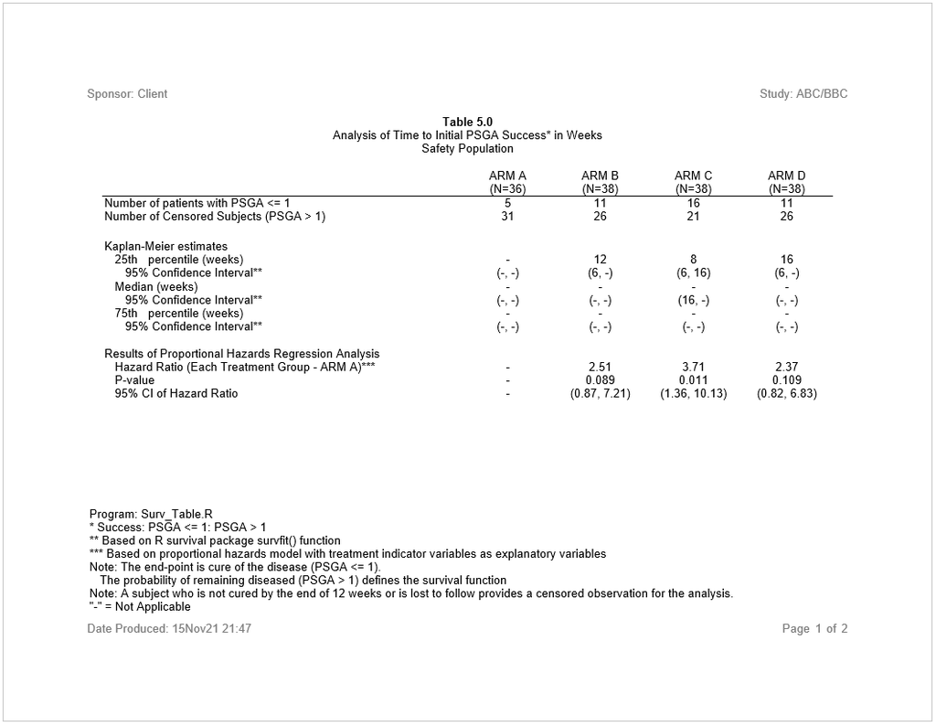

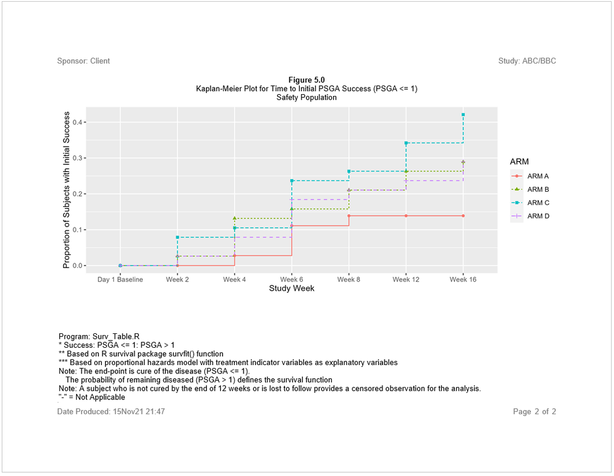

# Log

The above program produces the following log:

```
=========================================================================
Log Path: C:/Users/dbosa/AppData/Local/Temp/RtmpgrpGQ1/log/example5.log
Program Path: C:\packages\Testing\example5.R
Working Directory: C:/packages/Testing
User Name: dbosa
R Version: 4.1.2 (2021-11-01)
Machine: SOCRATES x86-64
Operating System: Windows 10 x64 build 19041
Base Packages: stats graphics grDevices utils datasets methods base
Other Packages: tidylog_1.0.2 survminer_0.4.9 ggpubr_0.4.0 survival_3.2-13 broom_0.7.10
                reporter_1.2.6 libr_1.2.1 fmtr_1.5.4 logr_1.2.7 sassy_1.0.5
                forcats_0.5.1 stringr_1.4.0 dplyr_1.0.7 purrr_0.3.4 readr_2.0.2
                tidyr_1.1.4 tibble_3.1.5 ggplot2_3.3.5 tidyverse_1.3.1
Log Start Time: 2021-11-21 15:30:37
=========================================================================

=========================================================================
Load and Filter Data
=========================================================================

# library 'adam': 2 items
- attributes: sas7bdat not loaded
- path: C:/Users/dbosa/Documents/R/win-library/4.1/reporter/extdata
- items:
    Name Extension Rows Cols     Size
1 adpsga  sas7bdat 1206   42 424.8 Kb
2   adsl  sas7bdat  152   56  98.7 Kb
         LastModified
1 2021-10-09 13:57:48
2 2021-10-09 13:57:48

lib_load: library 'adam' loaded

select: dropped 51 variables (STUDYID, SUBJID, SITEID, AGEU, RACE, )

filter: removed 2 rows (1%), 150 rows remaining

# A tibble: 150 x 5
   USUBJID    SEX   AGEGR1        AGE ARM
   <chr>      <chr> <chr>       <dbl> <chr>
```

[output cut: 606 more lines]

```
- title 2: 'Kaplan-Meier Plot for Time to Initial PSGA Success (PSGA <= 1)'
- title 3: 'Safety Population'

=========================================================================
Clean Up
=========================================================================

lib_sync: synchronized data in library 'adam'

lib_unload: library 'adam' unloaded

=========================================================================
Log End Time: 2021-11-21 15:30:39
Log Elapsed Time: 0 00:00:02
=========================================================================
```

Next: Full Program 6: Patient Profile